# Eigenface Notebook

```r
source("eigenfaces.R")
library(plyr)
library(knitr)
library(kableExtra)
library(ggplot2)
library(gridExtra)
library(factoextra)
library(caret)
library(gbm)
```

## Introduction

The 1991 article *Eigenfaces for Recognition* was formative for the multimedia research fields (Turk and Pentland 1991). The dataset, which predates the *Eigenfaces for Recognition* article, has since become a benchmark for computer vision and machine learning.

The data consists of 3993 pictures of human faces at a resolution of 128 x 128 in 8-bit grayscale. Data can be obtained from [MIT](http://courses.media.mit.edu/2004fall/mas622j/04.projects/faces/).

## Data Import

The eigenface rawdata is packaged with this repository and can be loaded with the following code. Two pictures were remove from the rawdata as provided from MIT because they were of incorrect dimensions: 2416 and 2412. Moreover, 22 faces are removed for having no parsed information.

```r
source("eigenfaces.R")
dat<-importFaceMatrix()
```

Each picture is represented as vector of length 128<sup>2</sup>=16,384. This vector can be reshaped into a raster, which can be colored with a color scale — grayscale in our case. Three random faces have been generated below.

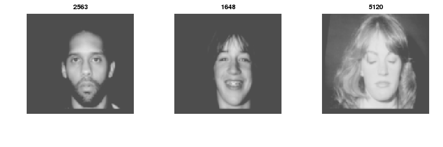

```r
#This code may be run multiple times to see the huge diversity of images in the data.
par(mfrow=c(1,3))
selected<-sample(rownames(dat),3)
{plotImage(dat[selected[1],],selected[1])
plotImage(dat[selected[2],],selected[2])
plotImage(dat[selected[3],],selected[3])}
```

## Metadata Import

The metadata comes from MIT already split into two sets, training and testing.

```r
meta_TR<-importMetaMatrix("faces/faceDR")
meta_T<-importMetaMatrix("faces/faceDS")
meta_TR<-meta_TR[meta_TR$n %in% rownames(dat),] # Remove any examples from metadata that are not in the data.
meta_T<-meta_T[meta_T$n %in% rownames(dat),]
dat_TR<-dat[meta_TR$n,]
dat_T<-dat[meta_T$n,]
#rm(dat)
```

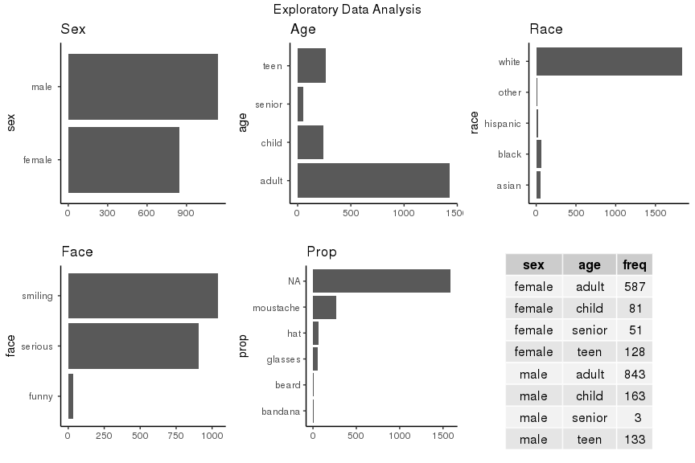

## Average faces

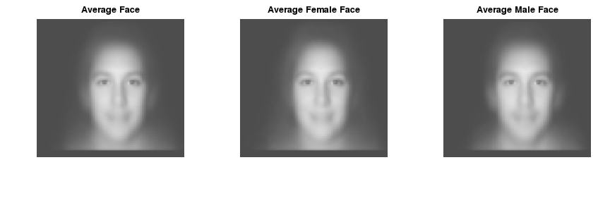

## Eigen faces

```r
pca.res<-prcomp(dat_TR,center=TRUE,rank. = params$n_features)
```

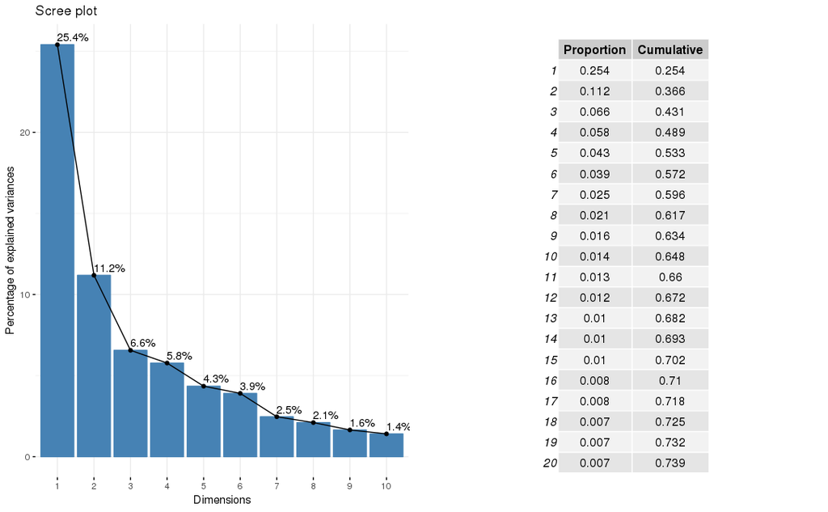

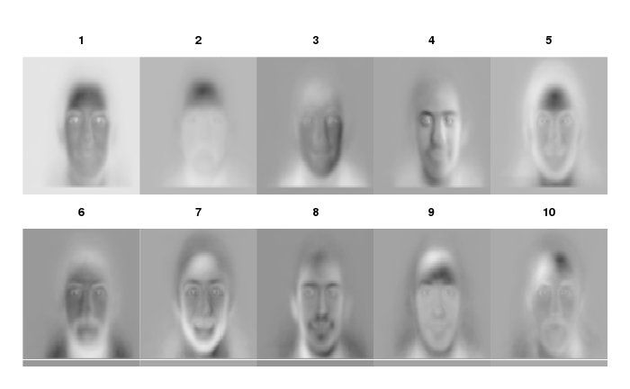

# ML with Caret

NZV filtering removes features that satisfy either of the following two conditions: 1. the frequency of the most prevalent value over the second most frequent value (called the “frequency ratio’’), which would be near one for well-behaved predictors and very large for highly-unbalanced data. 2. the “percent of unique values’’ is the number of unique values divided by the total number of samples (times 100) that approaches zero as the granularity of the data increases

```r
nzv<-nearZeroVar(dat_TR)
NZV_dat_TR<-dat_TR[,-nzv]
```

```r
library(doSNOW)
cl <- makeCluster(4)
  registerDoSNOW(cl)
#cormat<-cor(dat_TR)
#melted_cormat <- melt(cormat)
registerDoSEQ()
fitControl <- trainControl(## 10-fold CV
                           method = "repeatedcv",
                           number = 10,
                           ## repeated ten times
                           repeats = 10)
meta_TR$sex<-as.factor(meta_TR$sex)
#levels(meta_TR$sex)<-list("f"=c(" female "),"m"=c(" male "))
training<-data.frame(Sex=meta_TR$sex,NZV_dat_TR)
trainIndex <- createDataPartition(training$Sex, p = .3,
                                  list = FALSE,
                                  times = 1)
training_training<-training[trainIndex,]
training_test<-training[-trainIndex,]
preProcValues <- preProcess(training, method = c("center", "scale"))
trainTransformed <- predict(preProcValues, training_training)
testTransformed <- predict(preProcValues, training_test)

gbmFit1 <- train(Sex ~ ., data = training_training,
                 method = "gbm",
                 trControl = fitControl,
                 ## This last option is actually one
                 ## for gbm() that passes through
                 verbose = FALSE)
```

# References

Turk, Matthew, and Alex Pentland. 1991. “Eigenfaces for Recognition.” *Journal of Cognitive Neuroscience* 3 (1): 72–86.